# 3.0.8. Interpretabilidad

[figure not shown]

Realizado por:

*Sergio Ranz Casado*  
*Marcos Medina Cogolludo*

## 3.0.8. INTERPRETABILIDAD.

La [`interpretabilidad`](https://christophm.github.io/interpretable-ml-book/interpretability.html) en Machine Learning es el grado de comprensión que tiene un ser humano sobre la decisión que toma un algoritmo. Es decir, la explicación o el razonamiento que le da a la conclusión final. Muchas veces, un algoritmo puede predecir con fiabilidad un problema planteado con soluciones no contempladas por el ser humano a la hora de introducir los datos. Es por ello que queremos interpretar los datos que hemos obtenido de nuestro mejor modelo, [`LightGBM`](http://localhost:8888/notebooks/Desktop/CUNEF/Practica%20Machine%20Learning/project_template/notebooks/3.0.5.%20Modelos%20LightGBM.ipynb).

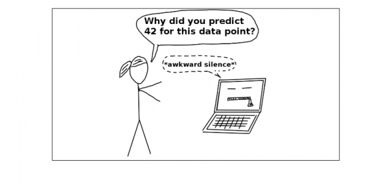

Para interpretar nuestro modelo utilizaremos una combinación de los modelos de interpretación de [`ELI5`](https://eli5.readthedocs.io/en/latest/) y [`LIME`](https://lime.readthedocs.io/en/latest/) llamada [`SHAP o (SHapley Additive exPlanations)`](https://shap.readthedocs.io/en/latest/index.html) que contiene un enfoque de teoria de juegos para explicar el resultado de cualquier modelo de aprendizaje automático.

El objetivo de `SHAP` es explicar la predicción de una instancia x calculando la contribución de cada característica a la predicción.

#### Importamos las librerias:

```python
import warnings
warnings.filterwarnings('ignore')
```

```python
import pandas as pd
import pyarrow.csv as pv
import pyarrow.parquet as pq
import seaborn as sns
import numpy as np
from matplotlib import pyplot as plt
from matplotlib import pyplot
from sklearn import preprocessing
import pandas as pd
import pyarrow.csv as pv
import pyarrow.parquet as pq
import seaborn as sns
from lightgbm import LGBMClassifier
import lightgbm as lgb
import time
import pickle
import shap
```

#### Importamos el train y test

```python
train = pd.read_parquet('../data/trainselect1.parquet')
test = pd.read_parquet('../data/testselect1.parquet')
```

```python
x_train = train.drop('c_sev',axis=1)
x_test = test.drop('c_sev',axis=1)
y_train = train['c_sev']
y_test = test['c_sev']
```

#### Modelo LightGBM + SHAP:

Conocemos que [`LightGBM`](https://lightgbm.readthedocs.io/en/latest/) tiene un parámetro que se puede utilizar de forma conjunta con SHAP. En la predicción de la probabilidad, podemos introducit el parámetro `pred_contrib = True` que te muestra los valores Shap para cada una de las observaciones. Lo que supondrá un mejor entendimiento para las personas de negocio.

Cargamos el modelo con pickle.

Nos encontramos con un problema y es que, el bucle tarda mucho por lo que, únicamente usaremos esto para los 500 primeros casos.

```python
%%time
filename = '../models/model5def.sav'
model5 = pickle.load(open(filename, 'rb'))
y_pred_lgbm = model5.predict(x_test)
print(y_pred_lgbm)
```

```
[1 0 0 ... 1 1 0]
Wall time: 379 ms
```

```python
%%time
# Escojo solo las 500 primeras muestras porque sino lleva mucho tiempo
pd_shap = pd.DataFrame(model5.predict(x_test.head(500), pred_contrib=True),
                       columns=list(x_test.columns)+['other']).drop(['other'], axis=1)
y_pred_lgbm_500 = pd.DataFrame(model5.predict(x_test.head(500)))
```

```
Wall time: 15 ms
```

```python
%%time
pd_contrib = pd.DataFrame({'contrib_1_max1':['0'],'contrib_1_max2':['0'],'contrib_1_max3':['0'],
                          'contrib_0_max1':['0'],'contrib_0_max2':['0'],'contrib_0_max3':['0']})

for i in range (pd_shap.shape[0]):
    list_contrib_1 = list(pd_shap.iloc[i,:].sort_values(axis=0, ascending=False).index[-3:])
    list_contrib_0 = list(pd_shap.iloc[i,:].sort_values(axis=0, ascending=False).index[:3])
    pd_row = pd.DataFrame([list_contrib_1 + list_contrib_0])
    pd_row.columns = pd_contrib.columns
    pd_contrib = pd.concat([pd_contrib, pd_row], axis=0)

pd_contrib = pd_contrib.iloc[1:,].set_index(y_pred_lgbm_500.index)
pd_contrib = pd.concat([y_pred_lgbm_500, pd_contrib], axis=1)
```

```
Wall time: 548 ms
```

```python
pd_contrib
```

|  | 0 | contrib_1_max1 | contrib_1_max2 | contrib_1_max3 | contrib_0_max1 | contrib_0_max2 | contrib_0_max3 |
| --- | --- | --- | --- | --- | --- | --- | --- |
| 0 | 1 | c_nums | c_rsur | c_vehs | c_traf | c_conf | c_rcfg |
| 1 | 0 | c_raln | c_rcfg | c_traf | c_rsur | c_nums | c_conf |
| 2 | 0 | c_raln | c_rsur | c_conf | c_hour | c_nums | c_wday |
| 3 | 1 | c_wday | c_rsur | c_traf | c_conf | c_hour | c_rcfg |
| 4 | 0 | c_rsur | c_hour | c_conf | c_nums | c_raln | c_vehs |
| ... | ... | ... | ... | ... | ... | ... | ... |
| 495 | 0 | c_raln | c_traf | c_conf | c_rcfg | c_rsur | c_hour |
| 496 | 1 | c_wday | c_rsur | c_traf | c_conf | c_hour | c_rcfg |
| 497 | 1 | c_wthr | c_nums | c_rsur | c_conf | c_traf | c_rcfg |
| 498 | 0 | c_rcfg | c_traf | c_conf | c_wthr | c_wday | c_vehs |
| 499 | 1 | c_nums | c_raln | c_rsur | c_conf | c_traf | c_hour |

500 rows × 7 columns

Como podemos observar, en función de cada casuística las variables principales van cambiando. Si que podemos observar por ejemplo, que para los accidentes mortales `(0)`, es muy importante el tramo de la carretera `c_raln` o el tipo de superficie `c_rsur` ademas del tipo de colisión `c_conf` que se ha tenido.

Sin embargo, este análisis sirve para cada caso en particular, nosotros nos queremos enfocar en el global de la predicción.

A continuación cargamos JS que es el codigo de visualización para notebook, y mostramos diferentes gráficos con Shap para interpretar nuestro modelo. Usaremos los siguientes gráficos:

- [`TREE SHAP`](https://medium.com/analytics-vidhya/shap-part-3-tree-shap-3af9bcd7cd9b): ·Es un algoritmo para calcular valores SHAP exactos para modelos basados en árboles de decisión.

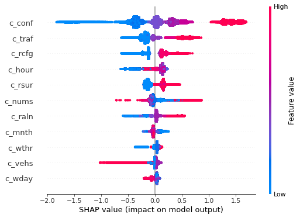

```
Wall time: 32.2 s
```

```python
%%time
shap.initjs()
explainer = shap.TreeExplainer(model5)
shap_values = explainer.shap_values(x_test)
shap.summary_plot(shap_values[1], x_test)
```

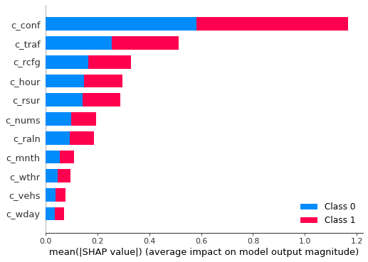

```
Wall time: 332 ms
```

```python
%%time
shap.initjs()
shap.summary_plot(shap_values, x_test)
```